# Preparing an analysis ready dataset

Which factors are associated with uncontrolled blood pressure in adults on treatment for hypertension?

Nicholas Hale

# Coversheet:

[figure not shown]

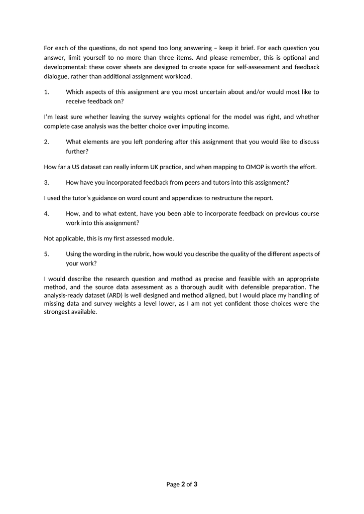

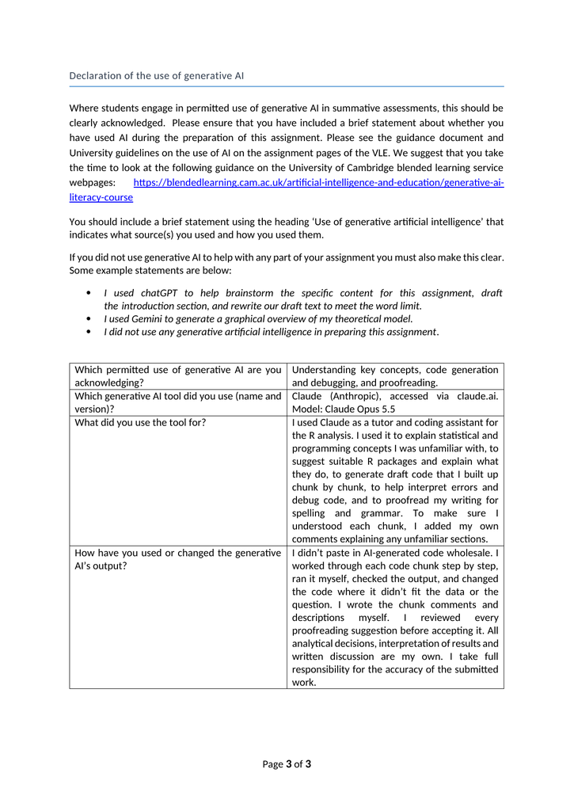

# Abstract:

**Background:** Many people treated for high blood pressure do not reach their target, which leaves them at risk of heart attack and stroke. Knowing which groups stay uncontrolled could help target future risk prevention.

**Aim:** To prepare a reusable data asset of people taking blood pressure medication, and an analysis ready dataset (ARD) for a logistic regression of factors associated with uncontrolled blood pressure in treated adults.

**Methods:** Six files from the National Health and Nutrition Examination Survey (NHANES) August 2021 to August 2023 were joined, renamed and checked at each stage. The data was built in four levels, from raw data to the ARD, with the last exclusions flagged rather than deleted. Uncontrolled blood pressure was defined as an average of up to three readings at or above the NICE thresholds. Predictors chosen were age, sex, ethnicity, BMI, income, diabetes and smoking.

**Results:** The curated asset holds 1,857 people on treatment. The ARD contains 1,572 adults, of whom 459 (29%) have uncontrolled blood pressure, giving more than 10 events per model parameter. 280 people (15%) were excluded for missing predictors, mainly income. A data dictionary, phenotype definitions and metadata are provided.

**Conclusion:** The question is feasible for a logistic regression of factors associated with control. The main limitations are single visit readings, self reported data (treatment, diabetes and smoking), missing income (which may not be random), and US data that may not transfer to other countries.

# Introduction:

## Background and literature:

High blood pressure is a leading cause of heart attack and stroke (World Health Organization, 2023). Yet many people on treatment remain uncontrolled: in the 2021 to 2023 NHANES cycle, around 32% of treated adults had blood pressure at or above 140/90 mmHg (Hardy et al., 2025). A PubMed search on 5 November 2026 returned 129 results, mostly US studies of blood pressure control using NHANES data. These studies found lower control in Black adults (Hayes et al., 2022), but unexpected findings for BMI and smoking. People with normal BMI were less often aware of their hypertension, but control among treated adults was broadly similar across BMI (Foti et al., 2022). Current smokers were less likely to be uncontrolled among non-Hispanic White adults, but not among non-Hispanic Black adults (Liu et al., 2017). A broader analysis found lower control in Black, Asian and other Hispanic adults and with lower income, but no link with BMI, smoking or diabetes (Soyombo et al., 2026). However, no study was found modelling these factors in treated adults in the 2021 to 2023 cycle at the UK (National Institute for Health and Care Excellence (NICE), 2019) thresholds of 140/90 mmHg, or 150/90 mmHg from age 80. Soyombo et al. (2026) used 2013 to 2018 data and a 130/80 mmHg threshold, while Hardy et al. (2025) only described control rates, without modelling the factors associated with them. This project prepares a dataset to enable that analysis and future analyses of treated blood pressure.

## Research question and method alignment:

**Research question:** Among adults taking medication for high blood pressure, which factors are associated with uncontrolled blood pressure? Table 1 shows how the data, method and question fit together. This report prepares the dataset. It will not run the final model.

| Part | Choice | Reason |
| --- | --- | --- |
| Data | NHANES, August 2021 to August 2023 (Centers for Disease Control and Prevention, 2024) | Measured blood pressure; a national community sample; the most recent cycle, free to download |
| Population | Adults 18 and over, examined, taking blood pressure medication, with at least one reading, not pregnant (Figure 1) | Treated patients, so control reflects treatment |
| Outcome | Uncontrolled (1) or controlled (0): average 140/90 mmHg or higher, or 150/90 mmHg from age 80 | UK clinic targets (NICE, 2019) |
| Predictors | Age, sex, ethnicity, body mass index, income, diabetes and smoking, chosen in advance | Studied in earlier NHANES work (Ostchega et al., 2018; Hayes et al., 2022; Soyombo et al., 2026); diabetes is common and affects blood pressure; mixed findings for BMI and smoking (Foti et al., 2022; … |
| Method | Logistic regression, results as odds ratios | The outcome is yes/no; each factor is adjusted for the others, unlike a chi-squared test, which looks at one factor at a time. Because uncontrolled blood pressure is common (29%), odds ratios will loo… |
| Data shape | One row per person, a yes/no outcome, no missing values | What logistic regression needs, with enough uncontrolled cases per parameter (Table 4) |
| Survey design | Weights, strata and sampling units kept | Correct for uneven sampling and nonresponse; needed for US population estimates, optional for the association model |

# Data asset overview:

This data asset is a curated dataset of people on blood pressure treatment, built from NHANES 2021 to 2023 for reuse by any service or researcher working on treated hypertension. It draws on six NHANES files: demographics and survey design (DEMO_L), the blood pressure questionnaire (BPQ_L) and readings (BPXO_L), body measures (BMX_L), the diabetes (DIQ_L) and smoking (SMQ_L) questionnaires. Figure 1 shows its four levels and the type of question each one suits: level 2 is the curated asset (`treated_bp.csv`) and level 3 is the ARD (`ard.csv`). Level 1 suits questions that include untreated people, such as prevalence. Level 2 suits other questions about treated people, for example imputing the missing incomes. Level 3 is ready for complete case models of these seven predictors.

[interactive chart not shown]

Figure 1: Levels of the data asset and where to stop for each use

# Methods:

The question came from clinical practice, and its feasibility was checked before the dataset was built (checks F1 to F5 in Table 4). It was deemed provisionally feasible, confirmed once complete case losses were known (Table 4).

## Source data assessment:

### Data Origin:

NHANES is run by the US National Center for Health Statistics and combines a home interview with a physical examination in a mobile examination centre. Blood pressure was measured three times at one visit, with an automated upper arm monitor after five minutes’ rest. This cycle used a redesigned sample and revised procedures after the pandemic. Pooling with the 2017 to March 2020 cycle was considered to increase numbers, but CDC advises caution when comparing across the pandemic gap (National Center for Health Statistics, 2024), and with 459 events pooling was unnecessary.

### Structure of the Data:

The six NHANES files cover different numbers of people, from 7,801 for the blood pressure readings to 11,933 for demographics, because not everyone takes every part of the survey. Blood pressure is only measured in people who attend the examination and are aged 8 or over, and some questions are only asked at certain ages. Some blanks are also by design: only people told they had high blood pressure are asked about medication. The files were joined by participant ID onto the demographics file, the only one that includes everyone. No participant was lost, and each person appears once (check F1, Table 4).

### Bias:

Selection and generalisability: NHANES samples groups unevenly and not everyone responds. The survey weights correct for this, but only towards the US population, and are kept for US estimates (check Q1). The sample therefore follows US ethnic categories and proportions, so findings may not transfer to other countries, and small groups such as the 74 Non-Hispanic Asian participants give less precise estimates. Measurement: all readings come from one visit, and some people read higher in a clinic (the white coat effect), so uncontrolled blood pressure is probably overestimated. UK diagnosis uses home or ambulatory readings for this reason (NICE, 2019). Medication use, diabetes and smoking are self reported: undiagnosed diabetes is counted as no and smoking may be underreported, which would tend to weaken their apparent links with control. Finally, everything was measured at one visit, so a factor cannot be shown to cause uncontrolled blood pressure rather than follow from it.

### Plausibility of values:

No impossible readings were found. Some readings and BMI values were very high but possible, so they were kept, as removing real patients with severe disease would bias the dataset towards healthier people. Ages of 80 and income ratios of 5 are NHANES caps (top coding), not errors.

### Missing data:

In the curated asset (level 2), only three predictors have gaps: income (13%), BMI (2%) and smoking (0.4%). Blood pressure is complete because the 70 treated adults without a reading were removed. People missing a predictor were flagged and left out of the ARD (level 3; Figure 1), and Table 4 checks the effect (Q4, Q5).

## Decision flags and inclusion criteria:

Under 18s, pregnant participants and people missing a predictor are flagged rather than removed (Figure 1), so they stay in level 2 for other questions and for pooling with other datasets later.

## Phenotype definitions and metadata:

Table 2 gives the source and derivation rule for each phenotype. Control uses the NICE threshold (below 140/90 mmHg, or below 150/90 mmHg from age 80), because the question comes from UK clinical practice and NICE sets an age specific target, whereas US studies apply a single threshold to all ages, usually 140/90 or 130/80 mmHg. Blood pressure is the mean of the available readings, which smooths variation between readings and is the standard NHANES approach. Only 8 treated adults had fewer than three readings (6 with two, 2 with one). Self reported borderline diabetes is coded as no, as borderline means prediabetes rather than diabetes. Smoking status follows the standard CDC definition (Centers for Disease Control and Prevention, no date). In the derived variables, refused and don’t know are treated as missing. The original codes are kept in levels 1 and 2.

| Phenotype | NHANES source | Rule | SNOMED CT |
| --- | --- | --- | --- |
| Treated hypertension | BPQ020, BPQ150 | Told they have high blood pressure and taking medication | Hypertension 38341003 |
| Uncontrolled blood pressure | BPXOSY1-3, BPXODI1-3 | Average ≥140/90, or ≥150/90 at 80+ (NICE) | None; built from systolic 271649006 and diastolic 271650006 |
| Diabetes | DIQ010 | Told by a doctor; borderline counted as no | Diabetes 73211009 |
| Smoking status | SMQ020, SMQ040 | Never, former or current (CDC) | Never smoked 266919005, ex-smoker 8517006, smoker 77176002 |
| Pregnancy | RIDEXPRG | Pregnant at the exam (flag) | Pregnancy 77386006 |

The asset was not mapped to the OMOP common data model: OMOP stores each measurement as a separate row, but this analysis needs one row per person, and OMOP has no standard fields for the survey design variables the asset keeps. Standard codes (SNOMED CT) are recorded in Table 2 and the data dictionary (Table A1) instead, so the asset can be mapped to OMOP later if needed. This follows the FAIR principles (Wilkinson et al., 2016): the metadata makes the asset findable, public data and a rerunnable script make it accessible, standard codes make it interoperable, and the dictionary and phenotypes make it reusable.

# Results: the data product:

The data dictionary (Table A1) gives each ARD variable’s meaning, NHANES source, derivation and SNOMED CT code. The dataset level metadata (Table A2) records the source, size, build date, software, licence and author. Both are in Appendix A and saved with the data as data_dictionary.csv and dataset_metadata.csv.

## Characteristics of the ARD:

Table 3: Characteristics of the ARD (unweighted)

| **Characteristic** | **N = 1,572**<sup>1</sup> |
| --- | --- |
| Age (years) | 66 (58, 73) |
| Sex |  |
| Female | 844 (54%) |
| Male | 728 (46%) |
| Ethnicity |  |
| Mexican American | 75 (4.8%) |
| Non-Hispanic Asian | 74 (4.7%) |
| Non-Hispanic Black | 249 (16%) |
| Non-Hispanic White | 940 (60%) |
| Other Hispanic | 137 (8.7%) |
| Other or multiracial | 97 (6.2%) |
| BMI (kg/m2) | 31 (27, 36) |
| Income-to-poverty ratio | 2.58 (1.34, 4.55) |
| Diabetes | 465 (30%) |
| Smoking status |  |
| Current | 238 (15%) |
| Former | 552 (35%) |
| Never | 782 (50%) |
| Blood pressure |  |
| Controlled | 1,113 (71%) |
| Uncontrolled | 459 (29%) |

<sup>1</sup> Median (Q1, Q3); n (%)

## Checks and analytical readiness:

| Check | Question | Finding | Decision |
| --- | --- | --- | --- |
| F1 | One row per person after joining? | 11,933 IDs, all unique | No duplicates |
| F2 | Refused or don't know answers? | 33 people | Kept as codes, missing in the ARD |
| F3 | Who was examined? | 6,337 examined adults | Only examined people have readings |
| F4 | Who is treated? | 2,442 taking medication (interviewed) | Enough people for the question |
| F5 | Who has blood pressure readings? | 96.6% of examined adults | The outcome can be measured |
| Q1 | Does the sample look like the population? | Non-Hispanic White 58% unweighted, 61% weighted | Weights kept |
| Q2 | How many treated adults have no reading? | 70 people | People with no reading removed |
| Q3 | Are the values possible? | 0 impossible readings; 7 BMI over 60 | All values kept |
| Q4 | Are people left out different? | 31% uncontrolled vs 29% kept | Complete cases kept |
| Q5 | Is income linked to control? | Median income ratio 2.11 uncontrolled vs 2.79 controlled | Complete case loss may not be neutral |

[output cut: 2 more lines]

Table 4 lists every check run while building the dataset, in pipeline order. Feasibility checks (F) on the raw and selected data, quality checks (Q) on the curated asset (level 2) and readiness checks (R) on the ARD (level 3). The readiness checks show that the ARD meets each requirement set out in the Introduction. The planned model was fitted once only to show that it runs, and its results were not looked at or evaluated.

The model has 12 parameters, because ethnicity and smoking are split into categories. With 459 uncontrolled cases, this gives about 38 events per parameter, well above the rule of ten (Peduzzi et al., 1996).

People left out for missing predictors, mostly income, were similar to those kept (Q4). Income is linked to control (Q5), but whether income is missing is not, once the other variables are accounted for (Q6), so complete case odds ratios should not be biased (Bartlett, Harel and Carpenter, 2015). Level 2 keeps these people, so multiple imputation can still be run as a sensitivity analysis.

# Discussion:

## Replicability, reliability and validity:

Rerunning the pipeline on earlier cycles would need the treated phenotype redefined, as they ask about medication differently (BPQ050A, not BPQ150). For reliability, blood pressure is the average of up to three automated readings taken under a standardised protocol (limits in Bias). To check the outcome was built correctly, it was recalculated as Hardy et al. (2025) did, weighted and with a single 140/90 threshold: 31.2% of treated adults were uncontrolled, close to their 31.7% in the same cycle, although theirs was also age adjusted. This suggests the readings and treatment status were derived correctly.

## Reproducibility:

The ARD is reproducible: the report rebuilds every level from scratch and the checks in Table 4 rerun at every knit. Reruns depend on the CDC files staying unchanged, so the build date and package versions are recorded (Table A2 and Appendix B). To reproduce it:

1. Install R and RStudio. Any missing packages install automatically.
2. Open the R Markdown file in RStudio, with an internet connection, and click Knit.
3. The six NHANES files download directly from the CDC website, and the checks run automatically.
4. The knit writes the report and five files: `ard.csv`, `treated_bp.csv`, `data_dictionary.csv`, `phenotypes.csv` and `dataset_metadata.csv`.

The code is available on GitHub (https://github.com/NHH29/MSTHDSM1).

## Feasibility verdict:

The dataset’s strengths are measured blood pressure, a recent national sample and a pipeline that rebuilds every level from the public files. The question is feasible with NHANES 2021 to 2023 for a logistic regression of associations. The ARD has one row per person, a clearly defined outcome and 459 events, about 38 per model parameter and keeps the survey design variables needed for population estimates. The main uncertainties are not the number of people but the 280 adults left out of the ARD for missing data, mostly income, and the generalisability limits set out in Bias.

## Limitations and governance:

The 280 adults with missing data, mostly income, were left out of the ARD, which may not be neutral (Table 4). Only one NHANES cycle was used, and the prescriptions file with drug type and number was not included. Adherence is not recorded, so missed doses cannot be separated from too little treatment or resistant hypertension. Users should therefore treat results as associations in a US sample, use the weights for population estimates, and check the effect of missing income before drawing conclusions.

NHANES 2021 to 2023 was approved by the NCHS Ethics Review Board, and the public use files are deidentified, with ages 80 and over top coded at 80, and freely accessible. No linkage to other data was carried out.

# References:

Bartlett, J.W., Harel, O. and Carpenter, J.R. (2015) ‘Asymptotically unbiased estimation of exposure odds ratios in complete records logistic regression’, *American Journal of Epidemiology*, 182(8), pp. 730-736. doi:10.1093/aje/kwv114.

Centers for Disease Control and Prevention (no date) *National Health Interview Survey: adult tobacco use glossary*. Available at: https://www.cdc.gov/nchs/nhis/tobacco/tobacco_glossary.htm (Accessed: 11 November 2026).

Centers for Disease Control and Prevention, National Center for Health Statistics (2024) *National Health and Nutrition Examination Survey Data, August 2021-August 2023*. Hyattsville, MD: U.S. Department of Health and Human Services. Available at: https://wwwn.cdc.gov/nchs/nhanes/ (Accessed: 11 November 2026).

Foti, K. et al. (2022) ‘BMI and blood pressure control among United States adults with hypertension’, *Journal of Hypertension*, 40(4), pp. 741-748. doi:10.1097/HJH.0000000000003072.

Hardy, S.T. et al. (2025) ‘Trends in blood pressure control among US adults with hypertension, 2013-2014 to 2021-2023’, *American Journal of Hypertension*, 38(2), pp. 120-128. doi:10.1093/ajh/hpae141.

Hayes, D.K. et al. (2022) ‘Blood pressure control among non-Hispanic Black adults is lower than non-Hispanic White adults despite similar treatment with antihypertensive medication: NHANES 2013-2018’, *American Journal of Hypertension*, 35(6), pp. 514-525. doi:10.1093/ajh/hpac011.

Linneberg, A. et al. (2015) ‘Effect of smoking on blood pressure and resting heart rate: a Mendelian randomization meta-analysis in the CARTA Consortium’, *Circulation: Cardiovascular Genetics*, 8(6), pp. 832-841. doi:10.1161/CIRCGENETICS.115.001225.

Liu, X. et al. (2017) ‘Racial/ethnic disparity in the associations of smoking status with uncontrolled hypertension subtypes among hypertensive subjects’, *PLoS ONE*, 12(8), e0182807. doi:10.1371/journal.pone.0182807.

National Center for Health Statistics (2024) *National Health and Nutrition Examination Survey Analytic Guidance and Brief Overview for the August 2021-August 2023 Data Files*. Hyattsville, MD: Centers for Disease Control and Prevention. Available at: https://wwwn.cdc.gov/nchs/nhanes/ContinuousNhanes/OverviewBrief.aspx?Cycle=2021-2023 (Accessed: 18 November 2026).

National Institute for Health and Care Excellence (2019, updated 2023) *Hypertension in adults: diagnosis and management* (NICE guideline NG136). Available at: https://www.nice.org.uk/guidance/ng136 (Accessed: 18 November 2026).

Ostchega, Y. et al. (2018) ‘Factors associated with hypertension control in US adults using 2017 ACC/AHA guidelines: National Health and Nutrition Examination Survey 1999-2016’, *American Journal of Hypertension*, 31(8), pp. 886-894. doi:10.1093/ajh/hpy047.

Peduzzi, P. et al. (1996) ‘A simulation study of the number of events per variable in logistic regression analysis’, *Journal of Clinical Epidemiology*, 49(12), pp. 1373-1379. doi:10.1016/S0895-4356(96)00236-3.

Soyombo, E. et al. (2026) ‘Factors associated with uncontrolled blood pressure and its association with cardiovascular and all-cause mortality among adults receiving antihypertensive therapy: a retrospective cohort study using NHANES 2013-2018 linked mortality data’, *Cureus*, 18, e117143. doi:10.7759/cureus.117143.

Wilkinson, M.D. et al. (2016) ‘The FAIR Guiding Principles for scientific data management and stewardship’, *Scientific Data*, 3, 160018. doi:10.1038/sdata.2016.18.

World Health Organization (2023) *Global report on hypertension: the race against a silent killer*. Geneva: World Health Organization. Available at: https://www.who.int/publications/i/item/9789240081062 (Accessed: 18 November 2026).

# Appendix A: Metadata:

## Data dictionary:

| Variable | Description | NHANES source | SNOMED CT |
| --- | --- | --- | --- |
| id | Participant ID | SEQN | No standard code |
| age | Age in years (80 means 80 or over) | RIDAGEYR | Age 397669002 |
| sex | Male or female | RIAGENDR | Biological sex 734000001 |
| ethnicity | Race and Hispanic origin, six groups | RIDRETH3 | Ethnic group 372148003 (non-standard in OMOP) |
| bmi | Body mass index (kg/m2) | BMXBMI | Body mass index 60621009 |
| income_ratio | Family income divided by the poverty line (5 means 5 or more) | INDFMPIR | No standard code |
| diabetes | 1 if told by a doctor they have diabetes, 0 if not or borderline | DIQ010 | Diabetes 73211009 |
| smoking_status | Never, former or current smoker | SMQ020, SMQ040 | Never smoked 266919005, ex-smoker 8517006, smoker 77176002 |
| systolic_mean | Average systolic reading (mmHg), used to build the outcome | BPXOSY1-3 | Systolic blood pressure 271649006 |
| diastolic_mean | Average diastolic reading (mmHg), used to build the outcome | BPXODI1-3 | Diastolic blood pressure 271650006 |

[output cut: 4 more lines]

## Dataset metadata:

| Field | Value |
| --- | --- |
| Files created | ard.csv, treated_bp.csv, data_dictionary.csv, phenotypes.csv, dataset_metadata.csv |
| Source | NHANES August 2021 to August 2023, National Center for Health Statistics |
| Each row is | One participant |
| ARD size | 1,572 rows, 14 columns |
| Curated asset size | 1,857 rows, 31 columns |
| Missing values | None in the ARD; the curated asset keeps blanks and exclusion flags |
| Created | 2026-11-19 |
| Software | R version 4.6.1 (2026-06-24) |
| Code | https://github.com/NHH29/MSTHDSM1 |
| Licence | NCHS public-use data: cite NCHS, no attempt to identify participants |

[output cut: 1 more lines]